# Homework 4

## Problem 1. Random Geometry (2pts each, 8pts total)

Use Monte Carlo simulation to estimate the following geometric properties of shapes and solids. Use the following facts:

- The distance between $(x_1,y_1)$ and $(x_2,y_2)$ is $\sqrt{(x_2-x_1)^2+(y_2-y_1)^2}$
- The coordinates of a point on a unit circle at angle $\theta$ is $(\cos\theta,\sin\theta)$
- The area of a triangle with vertices $(x_i, y_i), i=1,2,3$ is $\frac12 \left|x_1(y_2 − y_3) + x_2(y_3 − y_1) + x_3(y_1 − y_2)\right|$
1. What is the the average distance between two points in a box with side lengths 5, 10 and 20?

```r
distance = function(x1, x2, y1, y2, z1, z2) {

  return(sqrt((x2-x1)^2 + (y2-y1)^2 + (z2-z1)^2))
}
```

```r
lx = 5
ly = 10
lz = 20

NMC <- 10000;
results <- rep( 0, NMC );

for( i in 1:NMC) {

  x1 = runif(1, 0, lx)
  y1 = runif(1, 0, ly)
  z1 = runif(1, 0, lz)

  x2 = runif(1, 0, lx)
  y2 = runif(1, 0, ly)
  z2 = runif(1, 0, lz)

  results[i] <- distance(x1, x2, y1, y2, z1, z2);
}

sum( results )/NMC
```

```
## [1] 8.498656
```

2. Three points uniformly at random are selected on a circle with radius 1. What is the average area of the triangle formed?

```r
triangle_area = function(x1, y1, x2, y2, x3, y3) {

  return(1/2 * abs(x1*(y2-y3) + x2*(y3-y1) + x3*(y1-y2)))
}
```

```r
NMC <- 10000;
results <- rep( 0, NMC );

for( i in 1:NMC) {

  theta1 = runif(1, 0, 2*pi)
  theta2 = runif(1, 0, 2*pi)
  theta3 = runif(1, 0, 2*pi)

  x1 = cos(theta1)
  y1 = sin(theta1)
  x2 = cos(theta2)
  y2 = sin(theta2)
  x3 = cos(theta3)
  y3 = sin(theta3)

  results[i] <- triangle_area(x1, y1, x2, y2, x3, y3);
}

sum( results )/NMC
```

```
## [1] 0.476881
```

3. Three points uniformly at random are selected on a circle with radius 1. What is the average perimeter of the triangle formed?

```r
perimeter = function(x1, y1, x2, y2, x3, y3) {

  return(sqrt((x2-x1)^2 + (y2-y1)^2) + sqrt((x3-x2)^2 + (y3-y2)^2) + sqrt((x1-x3)^2 + (y1-y3)^2))
}
```

```r
NMC <- 10000;
results <- rep( 0, NMC );

for( i in 1:NMC) {

  theta1 = runif(1, 0, 2*pi)
  theta2 = runif(1, 0, 2*pi)
  theta3 = runif(1, 0, 2*pi)

  x1 = cos(theta1)
  y1 = sin(theta1)
  x2 = cos(theta2)
  y2 = sin(theta2)
  x3 = cos(theta3)
  y3 = sin(theta3)

  results[i] <- perimeter(x1, y1, x2, y2, x3, y3);
}

sum( results )/NMC
```

```
## [1] 3.827781
```

4. Let $(X,Y)$ be a random point, where both $X$ and $Y$ are independent, standard normal random variables. What is the average distance between $(X_1,Y_1)$ and $(X_2,Y_2)$?

```r
random_standard_norm = function(x1, y1, x2, y2) {

  return(sqrt((x2-x1)^2 + (y2-y1)^2))
}
```

```r
NMC <- 10000;
results <- rep( 0, NMC );

for( i in 1:NMC) {

  x1 = rnorm(1)
  y1 = rnorm(1)

  x2 = rnorm(1)
  y2 = rnorm(1)

  results[i] <- random_standard_norm(x1, y1, x2, y2);
}

sum( results )/NMC
```

```
## [1] 1.773071
```

## Problem 2: Law of Large Numbers (1.5pts each, 7.5pts total)

For this next problem, we’re going to empirically demonstrate the law of large numbers by simulating $N$ observations of a random variable, and show the convergence of the sample mean to the theoretical mean. Consider a Poisson variable $X$ with $\lambda=13$. It should hopefully be clear from the definition of the Poisson that $E(X)=\lambda=13$.

1. Start by creating a data frame with 2 columns: a column named `n` that goes from 1, 2, …, up to 1000; and a second column named `x` which is just 1000 repeated observations of a Poisson random variable with `lambda=13`.
2. Next, create a third column named `xbar` that computes the “mean-thus-far” up to each row. E.g. if the first 3 values of `x` are 3, 1, 8, then the first 3 values of `xbar` should be 3, 2, 4, since 3=3, (3+1)/2=2, and (3+1+8)/3=4. (Hint: use the `cumsum()` function to take the cumulative sum of the `x` column, then divide by the number of observations so far)

```r
len = 1000
index_col <- 1:len
poasson <- rpois(len, 13)
cumulative = cumsum(poasson) / index_col

df <- data.frame(Index = index_col, Poasson = poasson, Cumulative = cumulative)
head(df)
```

```
##   Index Poasson Cumulative
## 1     1      18   18.00000
## 2     2       5   11.50000
## 3     3      18   13.66667
## 4     4      14   13.75000
## 5     5      18   14.60000
## 6     6      12   14.16667
```

3. Make a line plot showing xbar vs n. Add a red line at the theoretical mean. Comment on what you observe in the plot. Is this what you were expecting? (Don’t forget to add proper labels/titles).

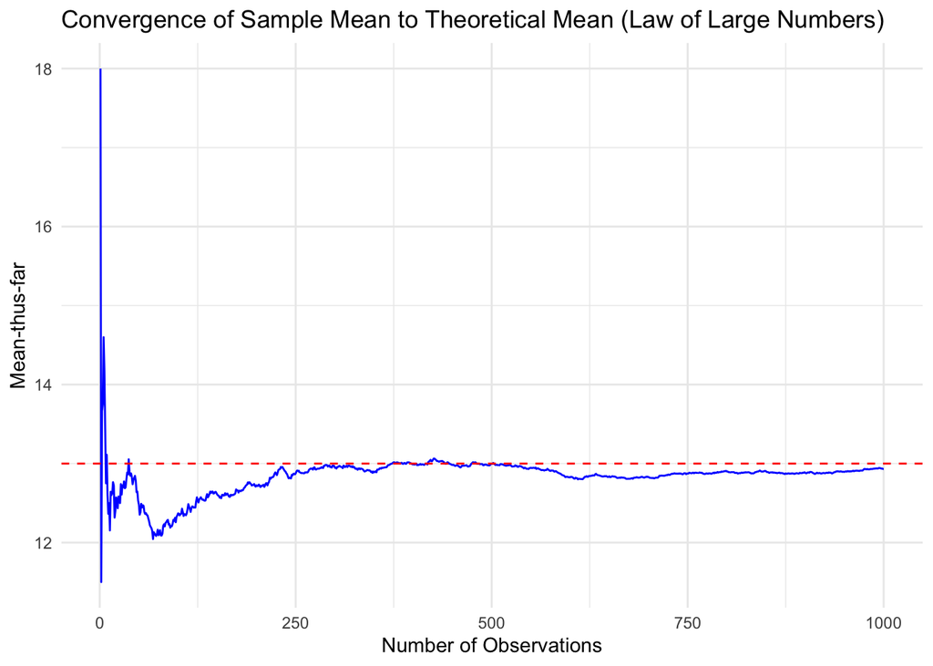

```r
# Create the line plot
ggplot(df, aes(x = index_col, y = cumulative)) +
  geom_line(color = "blue") +                     # Plot xbar vs n in blue
  geom_hline(yintercept = 13, color = "red", linetype = "dashed") +  # Add a red dashed line at the theoretical mean (13)
  labs(title = "Convergence of Sample Mean to Theoretical Mean (Law of Large Numbers)",
       x = "Number of Observations",
       y = "Mean-thus-far") +
  theme_minimal()
```

> What I expected: Initially, the sample mean may deviate significantly from the theoretical mean, but as the number of observations increases, the sample mean will converge to the theoretical mean of 13. This is a demonstration of the Law of Large Numbers, which states that the sample average approaches the expected value as the sample size increases. Observation: As you observe more and more Poisson samples, the sample mean stabilizes around 13, showing the consistency of the empirical mean with the theoretical mean, as expected.
4. Now, increase the number of simulations to 100,000 and remake the plot, this time with a log-scale x-axis to better show the rate of convergence across the entire axis. Comment again on the output. Explain if this does or does not empirically agree with the law of large numbers.

```r
len = 100000
index_col <- 1:len
poasson <- rpois(len, 13)
cumulative = cumsum(poasson) / index_col

df <- data.frame(n = index_col, Poasson = poasson, Cumulative = cumulative)
#print(df)
```

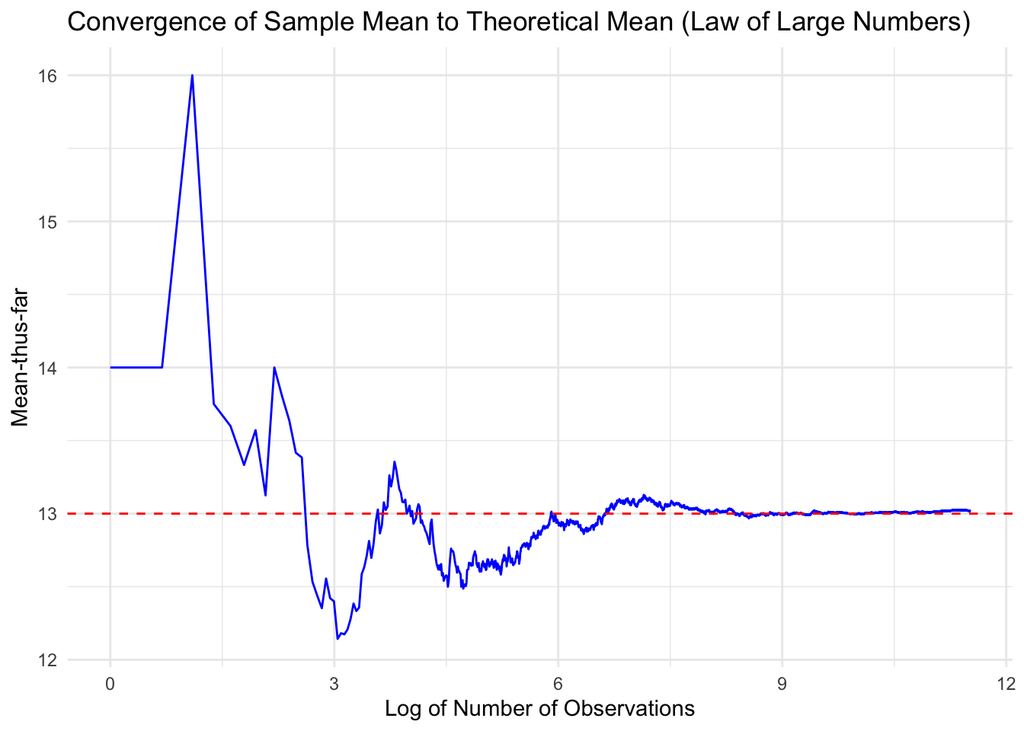

```r
# Create the line plot
ggplot(df, aes(x = log(index_col), y = cumulative)) +
  geom_line(color = "blue") +                     # Plot xbar vs n in blue
  geom_hline(yintercept = 13, color = "red", linetype = "dashed") +  # Add a red dashed line at the theoretical mean (13)
  labs(title = "Convergence of Sample Mean to Theoretical Mean (Law of Large Numbers)",
       x = "Log of Number of Observations",
       y = "Mean-thus-far") +
  theme_minimal()
```

> The empirical results with 100,000 simulations robustly agree with the Law of Large Numbers. The sample mean reliably converges to the theoretical mean of 13, and the use of a log-scale effectively showcases the rate and extent of this convergence across a wide range of observations.
5. Repeat the above steps with a **different** random variable. You can copy your entire code chunk so far and just make the necessary modifications. Comment on this output too and whether or not it also agrees with your expectations. Make sure you CLEARLY define what the random variable you’re using and clearly state what the expected value is (you may look this up on the internet if it’s a new random variable we covered this week that we did not give the expectation formula for in class).

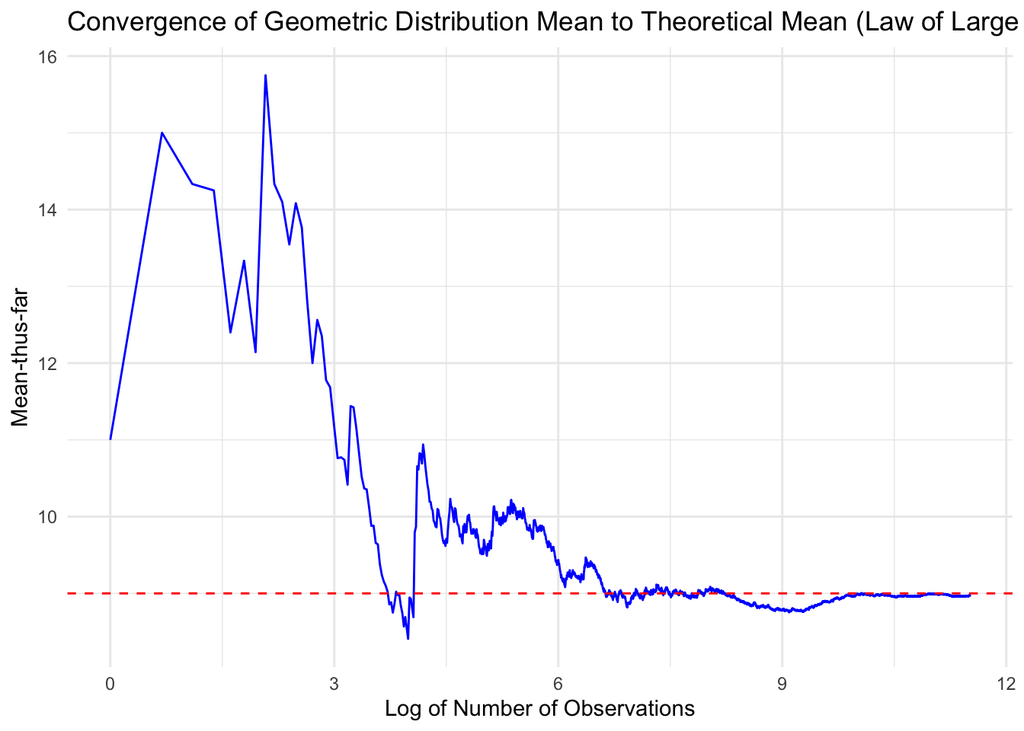

```r
# Set the new random variable parameters
len = 100000
p = 0.1  # Probability of success for Geometric distribution
expected_value = (1-p) / p  # Expected value for Geometric(p)

# Generate geometric random variables
index_col <- 1:len
geometric <- rgeom(len, p)
cumulative = cumsum(geometric) / index_col

# Create a data frame
df <- data.frame(n = index_col, Geometric = geometric, Cumulative = cumulative)

# Plot the line plot with log-scale x-axis
ggplot(df, aes(x = log(index_col), y = cumulative)) +
  geom_line(color = "blue") +  # Plot cumulative mean
  geom_hline(yintercept = expected_value, color = "red", linetype = "dashed") +  # Add red line at the theoretical mean (10)
  labs(title = "Convergence of Geometric Distribution Mean to Theoretical Mean (Law of Large Numbers)",
       x = "Log of Number of Observations",
       y = "Mean-thus-far") +
  theme_minimal()
```

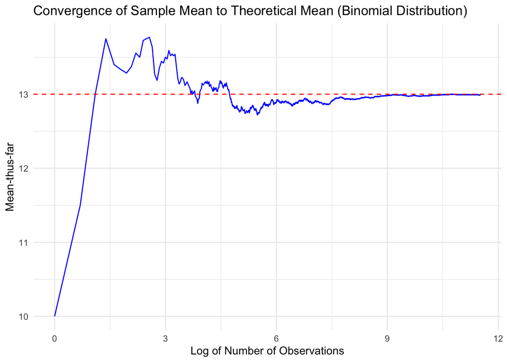

```r
# Set parameters for Binomial random variable
len = 100000
n_trials = 20
p_success = 0.65
expected_value = n_trials * p_success  # E(X) = 13

# Generate 100,000 Binomial observations
index_col <- 1:len
binomial <- rbinom(len, n_trials, p_success)
cumulative = cumsum(binomial) / index_col

# Create the data frame
df <- data.frame(n = index_col, Binomial = binomial, Cumulative = cumulative)

# Create the line plot
ggplot(df, aes(x = log(index_col), y = cumulative)) +
  geom_line(color = "blue") +                     # Plot xbar vs n in blue
  geom_hline(yintercept = expected_value, color = "red", linetype = "dashed") +  # Add a red dashed line at the expected mean (13)
  labs(title = "Convergence of Sample Mean to Theoretical Mean (Binomial Distribution)",
       x = "Log of Number of Observations",
       y = "Mean-thus-far") +
  theme_minimal()
```

## Problem 3: How Many Billies Can Fit? (1.5pts each, 7.5pts total)

You have an empty wall That is exactly 241 cm wide (with walls on either side). You see that Billy the Bookcase (https://www.ikea.com/us/en/p/billy-bookcase-white-00263850/) is 80cm wide, so you should be able to fit 3 in this space.

Suppose, however that The width of Billy is actually 80cm **on average**. In fact, the width is a normal random variable with a mean of 80 and a standard deviation of .5cm. (Please note - this is fictional! Ikea would never let quality control slip this bad). Use Monte Carlo simulation to answer the following questions:

1. Estimate the expected value and standard deviation for the total width of the 3 Billys.

```r
mean_billy = 80
sd_billy = 0.5
total = 241
NMC <- 10000

total_width <- replicate(NMC, sum(rnorm(3, mean = mean_billy, sd = sd_billy)))

estimated_mean = mean(total_width)
estimated_sd = sd(total_width)

estimated_mean
```

```
## [1] 240.0063
```

```r
estimated_sd
```

```
## [1] 0.8674971
```

2. If you buy 3 Billys, what is the probability that they will fit on your wall? Assume Billys are independent.

```r
bigger <- mean(total_width <= total)

bigger
```

```
## [1] 0.8758
```

```r
bigger2 <- total_width <= total #check

sum(bigger2) / NMC
```

```
## [1] 0.8758
```

3. How wide of a space would you need to be 99% sure that 3 Billys would fit? *Hint: Use the `quantile` function in R*

```r
qnorm(0.99, 3*mean_billy, sqrt(3)*sd_billy)
```

```
## [1] 242.0147
```

4. There are two other bookcases made by knockoff brand “Iqueeya”: Goat and Gruff. Goat bookcase widths are normally distributed with a mean of 79cm and a standard deviation of .25cm, while Gruff bookcase widths are normally distributed with a mean of 81cm and a standard deviation of .6cm. What is the probability that a Billy, a Goat and a Gruff will fit on your wall? (Assume independence)

```r
mean_goat = 79
mean_gruff = 81
sd_goat = 0.25
sd_gruff = 0.6

total_mean = mean_billy + mean_goat + mean_gruff

total_sd = sqrt(sd_billy + sd_goat + sd_gruff)

pnorm(total, total_mean, total_sd)
```

```
## [1] 0.8052882
```

5. Suppose you want the amount of gap between the bookcases and the side walls to be **as small as possible**. You assess how good of a fit you have by scoring: Buying 3 bookcases gives you a score of 0 if they don’t fit, but otherwise a score of
   $$\frac{\text{total width}}{241}\times
   100.$$
   What combination of Billys, Goats and Gruffs gives you the highest *expected score*?

```r
# Set the seed for reproducibility
set.seed(123)

# Number of simulations
n_sim <- 100000

# Wall width
wall_width <- 241

# Mean and standard deviation for each bookcase
mean_billy <- 80
sd_billy <- 0.5
mean_goat <- 79
sd_goat <- 0.25
mean_gruff <- 81
sd_gruff <- 0.6

# Scoring function
score <- function(width){
  scores <- rep(0, length(width))
  scores[width <= 241] <- width[width <= 241] / 241 * 100
  return(mean(scores))
}

# Simulate the total width for different combinations of bookcases
simulate_total_width <- function(billys, goats, gruffs, n_sim) {
  total_width <- replicate(n_sim,
                           sum(c(rnorm(billys, mean_billy, sd_billy),
                                 rnorm(goats, mean_goat, sd_goat),
                                 rnorm(gruffs, mean_gruff, sd_gruff))))
  return(total_width)
}

# Test different combinations of Billys, Goats, and Gruffs
combinations <- list(
  "3 Billys" = c(3, 0, 0),
  "2 Billys + 1 Goat" = c(2, 1, 0),
  "2 Billys + 1 Gruff" = c(2, 0, 1),
  "1 Billy + 2 Goats" = c(1, 2, 0),
  "1 Billy + 2 Gruffs" = c(1, 0, 2),
  "1 Billy + 1 Goat + 1 Gruff" = c(1, 1, 1),
  "3 Goats" = c(0, 3, 0),
  "3 Gruffs" = c(0, 0, 3),
  "2 Goats + 1 Gruff" = c(0, 2, 1)
)

# Evaluate the expected score for each combination
expected_scores <- sapply(combinations, function(comb) {
  total_width <- simulate_total_width(comb[1], comb[2], comb[3], n_sim)
  score(total_width)
})

# Output the expected scores for each combination
expected_scores
```

```
##                   3 Billys          2 Billys + 1 Goat
##                  87.135072                  98.790311
##         2 Billys + 1 Gruff          1 Billy + 2 Goats
##                  50.140428                  98.754261
##         1 Billy + 2 Gruffs 1 Billy + 1 Goat + 1 Gruff
##                  15.596696                  88.517244
##                    3 Goats                   3 Gruffs
##                  98.340418                   2.770433
##          2 Goats + 1 Gruff
##                  98.951688
```

```r
# Find the combination with the highest expected score
best_combination <- names(which.max(expected_scores))
cat("The combination with the highest expected score is:", best_combination, "\n")
```

```
## The combination with the highest expected score is: 2 Goats + 1 Gruff
```

```r
cat("Expected score:", max(expected_scores), "\n")
```

```
## Expected score: 98.95169
```

## Problem 4: Simulating a random variable (7pts)

Define a random variable $X$ with density
$$f_X(t) = \begin{cases}
\frac12\sin t &\mbox{ if } 0 \le t \le \pi \\
0 &\mbox{ otherwise. }
\end{cases}$$

The probability density function (pdf) is visualized below.

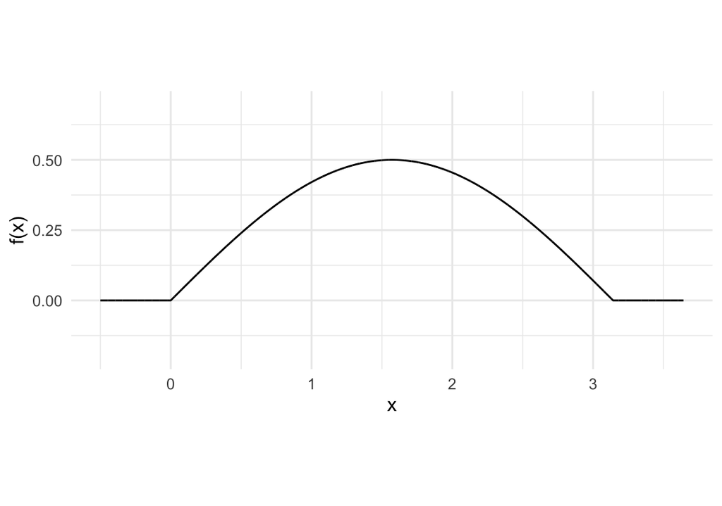

This means that the cumulative distribution function is
$$F_X(t)=\int_0^tf_X(u)du=\frac12-\frac{1}{2}\cos(t)$$
for $0 \le t \le \pi$, (and $F_X(t)=0$ for $t<0$ and $F_X(t) = 1$ for $t \ge \pi$).

1. (3 points) Find $F^{-1}(x)$, the inverse CDF. *Hint: In `R` the `arc-cosine` function is `acos()`.*

> F^−1(x)=arccos(1−2x),for 0≤x≤1.

```r
F_inv <- function(x) {
  acos(1 - 2 * x)
}
```

2. (4 points) Write a function `rx(n)` (like `rbinom`) to sample from this random variable, where `n` is the size of the sample to be drawn. Then, use your function to draw sample of size 1000 and plot a histogram of the output to verify the results make sense.

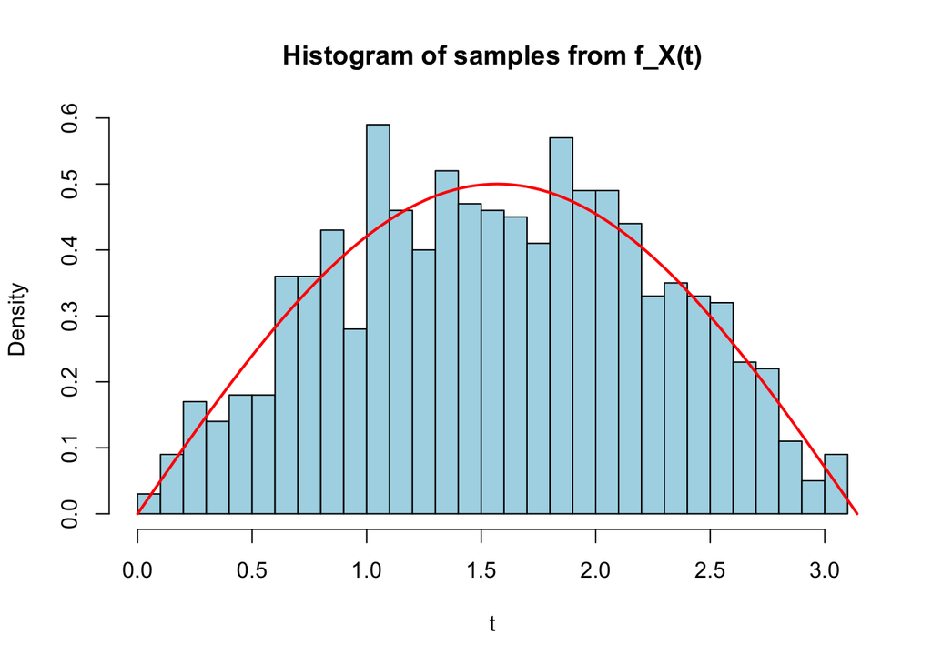

```r
# complete the function
rx <- function(n) {
u <- runif(n)
samples <- acos(1 - 2 * u)
return(samples)
}

# Draw a sample of size 1000
sample_size <- 1000
samples <- rx(sample_size)
# Plot a histogram of the samples
hist(samples, breaks = 30, probability = TRUE, main = "Histogram of samples from f_X(t)",
xlab = "t",  col = "lightblue", border = "black")
# Overlay the theoretical density f_X(t) = 0.5 * sin(t) for comparison
curve(0.5 * sin(x), from = 0, to = pi, add = TRUE, col = "red", lwd = 2)
```

```r
# The histogram should look like the PDF we plotted above.
# Un-comment the following lines of code and check it looks correct

#hist(rx(1000), probability=TRUE)
#lines(x=seq(0,pi,.01), y=pdf_x(seq(0,pi,.01)), col='red')
```